# Distributions (Part I)

### Hypergeometric distribution - gene mutation (s13)

In a mutation test of 12 genes, 8 genes were found mutated in a cancer cell. If one selects 6 genes randomly, what is the expected number of mutated genes and the probability of finding 4 mutated genes out of the 6 genes? What if the 120 genes were tested initially and got 80 mutated genes?

```r
N1 <- 12 # n = N-M
M1 <- 8 # M
n1 <- 6 # k
x1 <- 4 # x
Ex1 <- n1*M1/N1; Ex1
```

```
## [1] 4
```

```r
# p(X=4)
dhyper(x1, M1, N1 - M1, n1)
```

```
## [1] 0.4545455
```

```r
N2 <- 120 # n = N-M
M2 <- 80 # M
n2 <- 6 # k
x2 <- 4 # x

Ex2 <- n2*M2/N2; Ex2
```

```
## [1] 4
```

```r
# p(X=4)
dhyper(x2, M2, N2 - M2, n2)
```

```
## [1] 0.3377274
```

```r
# cf) for 1200
N3 <- 1200 # n = N-M
M3 <- 800 # M
n3 <- 6 # k
x3 <- 4 # x

Ex3 <- n3*M3/N3; Ex3
```

```
## [1] 4
```

```r
# p(X=4)
dhyper(x3, M3, N3 - M3, n3)
```

```
## [1] 0.3300438
```

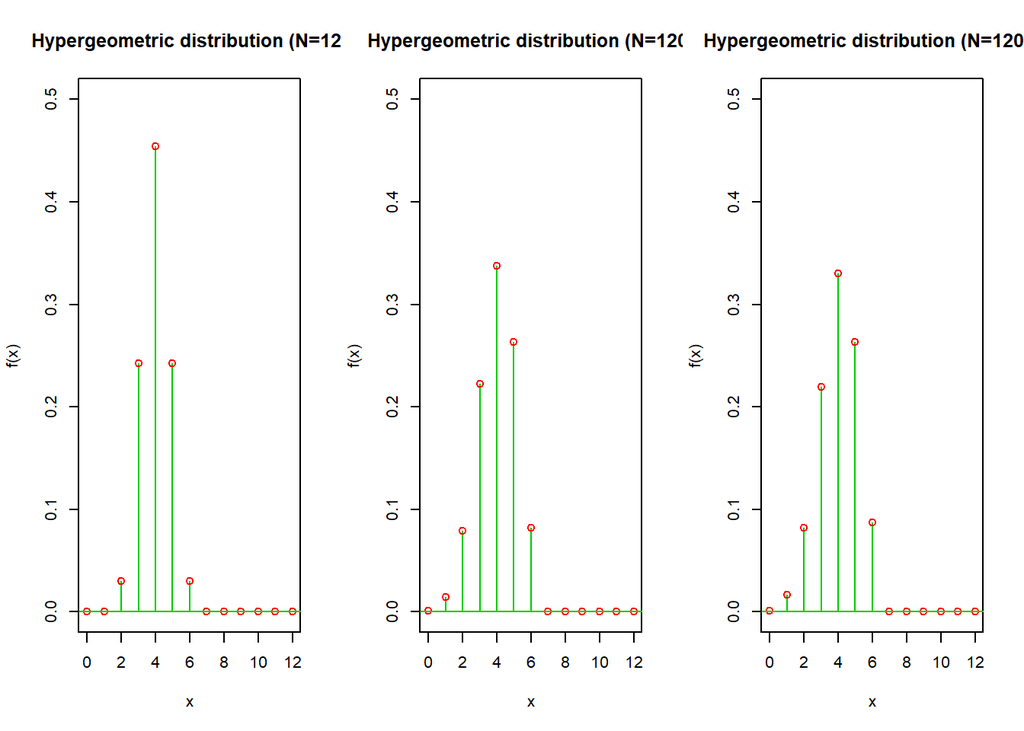

```r
par(mfrow = c(1,3))
plot(0:12, dhyper(0:12, M1, N1 - M1, n1), type = 'h',
     col = 3, ylim = c(0,0.5), xlab = 'x', ylab = 'f(x)',
     main = "Hypergeometric distribution (N=12)")
points(0:12, dhyper(0:12, M1, N1 - M1, n1), col = 2)
abline(h = 0, col = 3)

plot(0:12, dhyper(0:12, M2, N2 - M2, n2), type = 'h',
     col = 3, ylim = c(0,0.5), xlab = 'x', ylab = 'f(x)',
     main = "Hypergeometric distribution (N=120)")
points(0:12, dhyper(0:12, M2, N2 - M2, n2), col = 2)
abline(h = 0, col = 3)

plot(0:12, dhyper(0:12, M3, N3 - M3, n3), type = 'h',
     col = 3, ylim = c(0,0.5), xlab = 'x', ylab = 'f(x)',
     main = "Hypergeometric distribution (N=1200)")
points(0:12, dhyper(0:12, M3, N3 - M3, n3), col = 2)
abline(h = 0, col = 3)
```

```r
par(mfrow = c(1,1))

dhyper(x1, M1, N1 - M1, n1); dhyper(x2, M2, N2 - M2, n2); dhyper(x3, M3, N3 - M3, n3)
```

```
## [1] 0.4545455
```

```
## [1] 0.3377274
```

```
## [1] 0.3300438
```

### Negative Binomial distribution - baseball (s15)

The probability that Hanwha win against Doosan a game is 0.6, and Doosan win against Hanwha a game is 0.4. Find the probability that each team win the series by winning 4 games first out of 7 matches.

```r
x <- 3 # number of failures x
size <- 4 # until y-th success denoted as size
prob <- 0.6 # probability of Hanwha win

# Hanhwa win
pnbinom(x, size, prob)
```

```
## [1] 0.710208
```

```r
# Doosan win
pnbinom(x, size, 1 - prob)
```

```
## [1] 0.289792
```

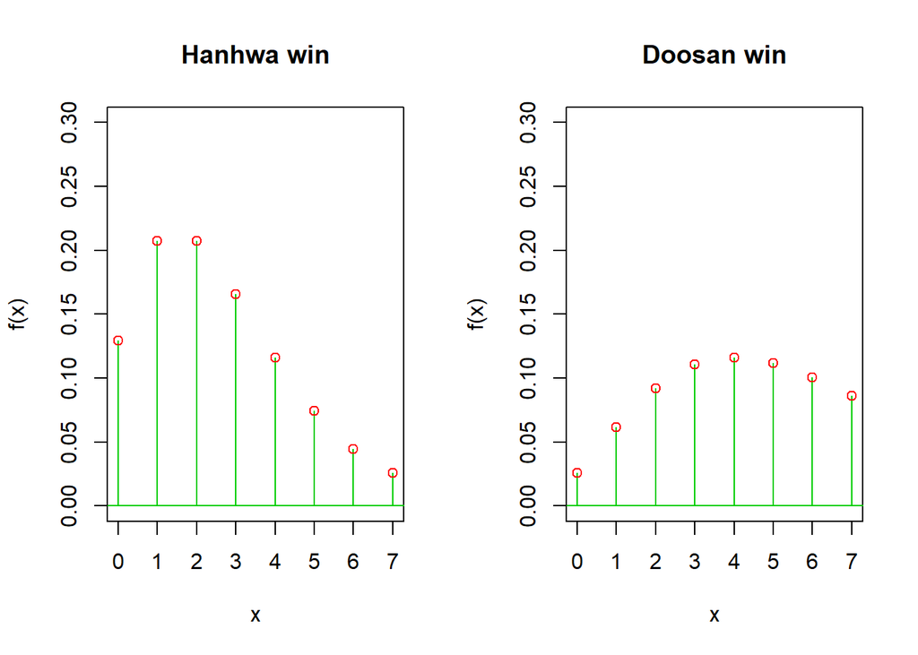

```r
par(mfrow = c(1,2))

plot(0:7, dnbinom(0:7, size, prob), type = 'h',
     col = 3, ylim = c(0,0.3), xlab = 'x', ylab = 'f(x)',
     main = "Hanhwa win")
points(0:7, dnbinom(0:7, size, prob), col = 2)
abline(h = 0, col = 3)

plot(0:7, dnbinom(0:7, size, 1 - prob), type = 'h',
     col = 3, ylim = c(0,0.3), xlab = 'x', ylab = 'f(x)',
     main = "Doosan win")
points(0:7, dnbinom(0:7, size, 1 - prob), col = 2)
abline(h = 0, col = 3)
```

```r
par(mfrow = c(1,1))
```

### Negative Binomial - gene expression (s15)

5% of the genes may express in a particular condition. What is the probability that we see two genes expressed under the same condition after examining at least five genes ? What is the mean trials to see two expressed genes?

```r
x <- 0:2 # number of failures x
size <- 2  # until y-th success denoted as size
prob <- 0.05

# P(X >= 5) = 1-P(X<5) = 1 - {P(X=2) + P(X=3) + P(X=4)}
# P(X=0), P(X=1) is not considered due to the constraint X>2.
1 - sum(dnbinom(x, size, prob))
```

```
## [1] 0.9859813
```

```r
# mean trials
size/prob
```

```
## [1] 40
```

### Geometric distribution - penalty kick (s17)

Assume that there is one soccer player, who made 20% of his attempted penalty kick goals in his career. Find the probability that he success first penalty kick after third attempts.

```r
x <- 0:2 # number of failures (or number of trial - 1)
prob <- 0.2 # probability of success

# P(X >= 3) = 1 - P(X < 4)
1 - sum(dgeom(x, prob))
```

```
## [1] 0.512
```

### Geometric distribution - Cell division (s17)

Assume that the probability of producing mutation at each cell division is 0.10. What is the probability to produce a mutation at the third division, and average number of required cell division before getting the first mutation?

```r
x <- 2 # number of failures (or number of trial - 1)
prob <- 0.1 # probability of success

# P(X=3)
dgeom(x, prob)
```

```
## [1] 0.081
```

```r
# E(x)
Ex <- 1/prob
Ex
```

```
## [1] 10
```

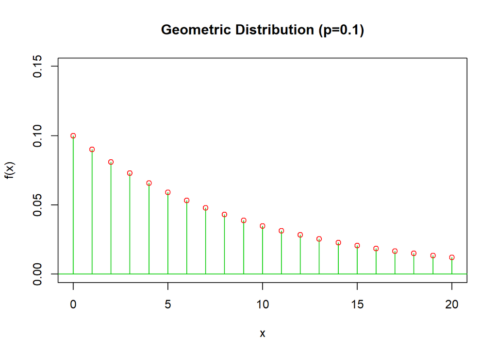

```r
# Plot
plot(0:20, dgeom(0:20, prob), type = 'h', col = 3, ylim = c(0,0.15),
     xlab = 'x', ylab = 'f(x)', main = "Geometric Distribution (p=0.1)")
points(0:20, dgeom(0:20, prob), col = 2)
abline(h = 0, col = 3)
```

### Poisson distribution - software error (s21)

Suppose that the number of errors in a piece of software has a Poisson distribution with parameter $\lambda = 3$. Find the probability that a piece of software has no errors and there are three or more errors in a piece of software.

```r
# no error
dpois(0, lambda = 3)
```

```
## [1] 0.04978707
```

```r
# three or more errors = 1 - less than 3 erros
1 - ppois(2, lambda = 3)
```

```
## [1] 0.5768099
```

### Poisson distribution - gene mutation (s21)

Suppose that the number of mutation for 10 genes is expected to be 18 in a particular species. What is the probability of finding no mutation in a gene of this species?

```r
# no mutation, lambda = 18 mutations / 10 genes
dpois(0, lambda = 1.8)
```

```
## [1] 0.1652989
```

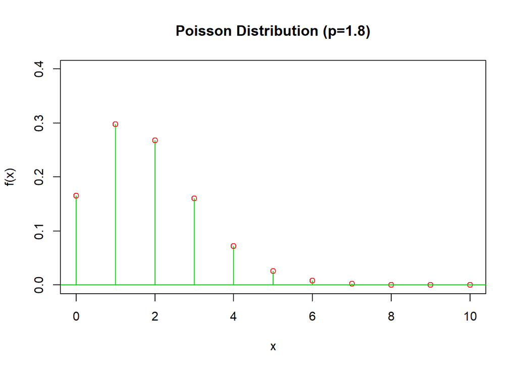

```r
# Plot
plot(0:10, dpois(0:10, lambda = 1.8), type = 'h',
     col = 3, ylim = c(0,0.4), xlab = 'x', ylab = 'f(x)',
     main = "Poisson Distribution (p=1.8)")
points(0:10, dpois(0:10, lambda = 1.8), col = 2)
abline(h = 0, col = 3)
```

```r
# Think about how the problem of Binomial Distribution can be transformed to
# that of Poisson Distribution.

n <- c(10, 100, 1000)
p <- c(0.18, 0.018, 0.0018)

dbinom(0, n, p)
```

```
## [1] 0.1374480 0.1626106 0.1650310
```

```r
# approximating binomial distribution using poisson distribution
# (when n is large, p is small)
lambda <- n*p
dpois(0, lambda)
```

```
## [1] 0.1652989 0.1652989 0.1652989
```

### Exponential Distribution (s23)

Cell division occurs according to the Poisson process with a mean rate of two divisions per six minutes. What is the probability that it will take at least five minutes for the first division of the cell to take place?

- $X$: the waiting time in minutes until the first cell division take place
- $X$ has an exponential distribution with $\lambda=2/6=1/3$

```r
# P(X > 5)
x <- 5
lambda <- 1/3

# f(x) = lambda*e^{-lambda * x}
1 - pexp(x, rate = lambda)
```

```
## [1] 0.1888756
```

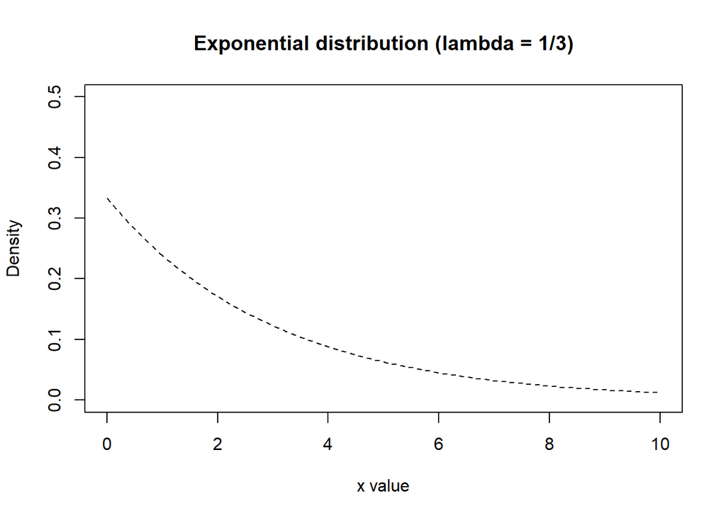

```r
x <- seq(0, 10, length = 100)
hx <- dexp(x, rate = lambda)
plot(x, hx, type = "l", lty = 2, xlab = "x value", ylim = c(0,0.5),
     ylab = "Density", main = "Exponential distribution (lambda = 1/3)")
```

### Geometric Approximation of Exponential Distribution (s23)

Assume that the probability of producing mutation at each cell division in the question of slide 17 (Geometric Distribution) follows the Poisson process. Recalculate it by applying Exponential distribution. Assume that the cell division time is 10 minutes. Calculate the probability to produce a mutation within 30 min, and average waiting time in minutes until the first mutation?

```r
# Exponential distribution
lambda <- 1/10
dexp(x = 2, rate = lambda)
```

```
## [1] 0.08187308
```

```r
Ex <- 1/lambda
Ex
```

```
## [1] 10
```

```r
# recall s17, Geometric approximation of exponential distribution
dgeom(x = 2, prob = 0.1)
```

```
## [1] 0.081
```

```r
Ex <- 1/0.1
Ex
```

```
## [1] 10
```

[figure not shown]

```r
# Plot
plot(0:20, dexp(0:20, lambda), type = 'h', col = 3,
     ylim = c(0,0.15), xlab = 'x', ylab = 'f(x)',
     main = "Approximation of exponential distribution by geometric distribution")
points(0:20, dexp(0:20, lambda), col = 2)
abline(h = 0, col = 3)
lines(0:20, dgeom(0:20, prob = 0.1), col = 1, lty = 3)
legend("topright", legend = c("Exponential", "Geometric"), col = c("black", "green"),
       lty = c(3, 1))
```

### Gamma Distribution (s25)

Suppose we are interested in how long it will take for 20 metal sheets to be delivered to the panel construction lines where the delivery rate is 1.6 sheet/unit time. Find the expectation and variance of the waiting time.

$f(x)= \frac{1}{(s^{a} \Gamma(a))} x^{(a-1)} e^{-(x/s)}$

```r
k <- 20 # shape = a = k
lambda <- 1.6 # scale = s = 1/lambda

Ex <- k/lambda
Var <- k/lambda^2
Ex; Var
```

```
## [1] 12.5
```

```
## [1] 7.8125
```

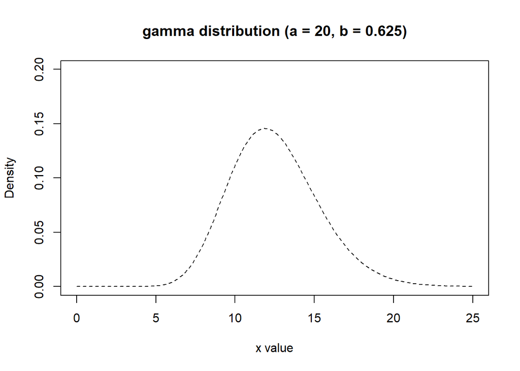

```r
x <- seq(0, 25, length = 100)
hx <- dgamma(x, shape = k, scale = 1/lambda)
plot(x, hx, type = "l", lty = 2, xlab = "x value", ylim = c(0,0.2),
     ylab = "Density", main = "gamma distribution (a = 20, b = 0.625)")
```